# Pemodelan dan Peramalan ARIMA Suhu Rata-rata Harian Kota Bogor

Tugas Mata Kuliah Metode Peramalan Deret Waktu

Astra Dama - M0401241130

01 October 2026

# 1 Pendahuluan

Dokumen ini membangun model **ARIMA** untuk data **suhu rata-rata Kota Bogor**. Data asli berupa suhu per jam. Karena data per jam memiliki pola musiman harian (siklus 24 jam) yang tidak dapat ditangani oleh ARIMA non-musiman, data **diagregasi menjadi rata-rata harian**. Tahapan yang dikerjakan:

1. Pembagian data train dan test
2. Uji kestasioneran data train (rataan: ACF dan ADF, ragam: Box-Cox)
3. Penanganan ketidakstasioneran (transformasi dan/atau differencing)
4. Identifikasi model potensial (ACF, PACF, EACF)
5. Pendugaan parameter, uji signifikansi, dan perbandingan AIC
6. Analisis sisaan
7. Overfitting
8. Peramalan

# 2 Persiapan Data

## 2.1 Membaca dan Mengagregasi Data

| Tanggal | Suhu | n_jam |
| --- | --- | --- |
| 2025-01-01 | 24.69167 | 24 |
| 2025-01-02 | 26.17083 | 24 |
| 2025-01-03 | 26.28333 | 24 |
| 2025-01-04 | 25.98333 | 24 |
| 2025-01-05 | 26.19167 | 24 |
| 2025-01-06 | 25.98750 | 24 |

```
#>    Min. 1st Qu.  Median    Mean 3rd Qu.    Max.
#>   23.25   25.28   25.93   25.89   26.51   28.72
```

**Interpretasi:** Data per jam sebanyak 12384 observasi diagregasi menjadi 516 hari (2025-01-01 s.d. 2026-05-31). Setiap hari terdiri dari 24 jam lengkap, sehingga rata-rata harian dapat dipercaya. Suhu rata-rata harian berada pada rentang 23.25 sampai 28.72 °C dengan rata-rata 25.89 °C.

## 2.2 Plot Data Keseluruhan

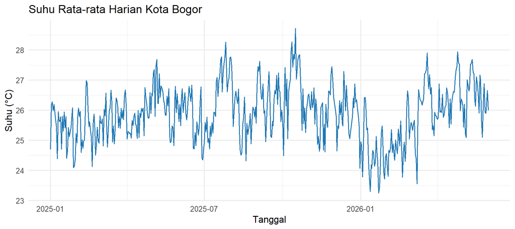

**Interpretasi:** Secara visual, suhu harian berfluktuasi di sekitar suatu level tertentu tanpa tren naik atau turun yang tegas. Ada variasi antar-hari yang cukup acak dan kemungkinan variasi antar-bulan. Data baru mencakup sekitar 17 bulan, jadi satu siklus tahunan belum bisa dinilai secara penuh. Kestasioneran akan dibuktikan secara formal pada tahap 3.

# 3 Pembagian Data Train dan Test (Tahap 1)

| Set | Jumlah | Awal | Akhir |
| --- | --- | --- | --- |
| Train | 413 | 2025-01-01 | 2026-02-17 |
| Test | 103 | 2026-02-18 | 2026-05-31 |

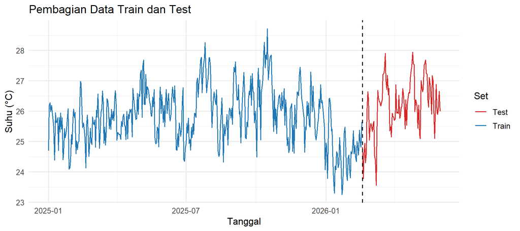

**Interpretasi:** Data dibagi secara berurutan (bukan acak, karena data deret waktu) dengan rasio 80:20. Data train sebanyak 413 hari dipakai untuk membangun model, dan data test sebanyak 103 hari disimpan untuk menguji akurasi ramalan. Seluruh tahap 2 sampai 7 hanya memakai data train.

# 4 Uji Kestasioneran Data Train (Tahap 2)

## 4.1 Kestasioneran dalam Rataan (Plot, ACF, dan ADF)

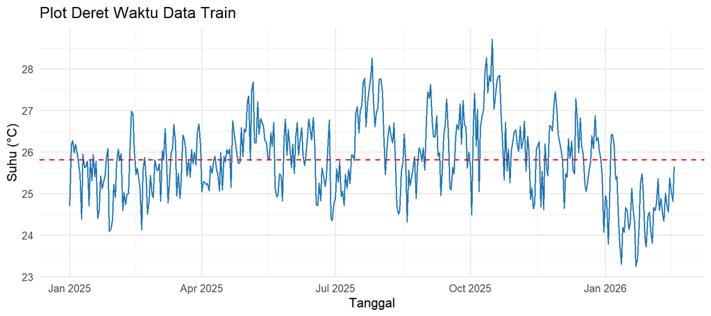

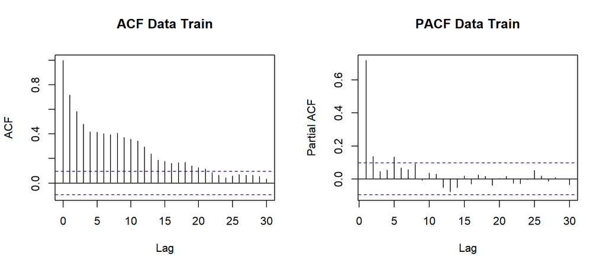

```
#>
#>  Augmented Dickey-Fuller Test
#>
#> data:  as.numeric(y_train)
#> Dickey-Fuller = -3.3139, Lag order = 7, p-value = 0.06867
#> alternative hypothesis: stationary
```

## 4.2 Kestasioneran dalam Ragam (Box-Cox)

Stasioner dalam ragam apabila selang kepercayaan 95% dari nilai $\lambda$ **mengandung angka 1**. Selang diperoleh dari profil log-likelihood Box-Cox, yaitu semua nilai $\lambda$ dengan log-likelihood lebih besar dari $\ell_{max} - \chi^2_{1;0.95}/2$. Perhitungan ini ekuivalen dengan `MASS::boxcox()`.

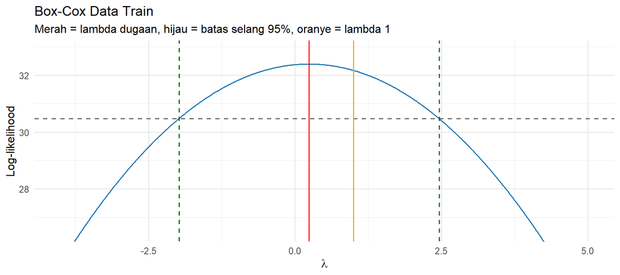

| Lambda_dugaan | Batas_bawah | Batas_atas | Mengandung_1 |
| --- | --- | --- | --- |
| 0.24 | -1.98 | 2.46 | Ya |

**Interpretasi:** Nilai $\hat\lambda$ = 0.24 dengan selang kepercayaan 95% (-1.98; 2.46). Selang tersebut **mengandung angka 1**, sehingga data **sudah stasioner dalam ragam** dan tidak perlu transformasi.

# 5 Penanganan Ketidakstasioneran (Tahap 3)

## 5.1 Transformasi (Jika Ragam Tidak Stasioner)

**Interpretasi:** Karena selang kepercayaan sudah mengandung 1, **tidak dilakukan transformasi** dan data train dipakai apa adanya ($\lambda$ = 1).

## 5.2 Differencing (Jika Rataan Tidak Stasioner)

Keputusan differencing diambil dari uji ADF pada data (hasil transformasi, bila ada). Differencing diulang sampai stasioner dengan batas maksimal d = 2, kecuali `d_manual` diisi.

| Data | Statistik_ADF | P_value | Keputusan |
| --- | --- | --- | --- |
| Sebelum differencing | -3.3139 | 0.0687 | Tidak stasioner |
| Setelah differencing (d = 1) | -10.4455 | 0.0100 | Stasioner |

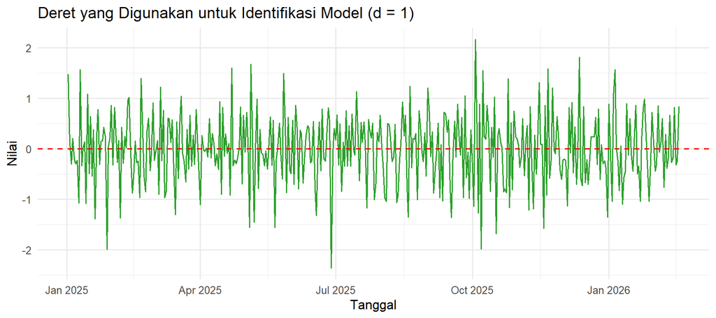

**Interpretasi:** Data awal belum stasioner (p-value ADF 0.0687), sehingga dilakukan differencing sebanyak **d = 1**. Setelah differencing, p-value ADF menjadi 0.0100 (< alpha), sehingga data sudah stasioner. Plot di atas menunjukkan deret yang akan dipakai untuk mengidentifikasi model, yang seharusnya berfluktuasi di sekitar rataan konstan (garis merah).

# 6 Identifikasi Model Potensial (Tahap 4)

## 6.1 ACF dan PACF

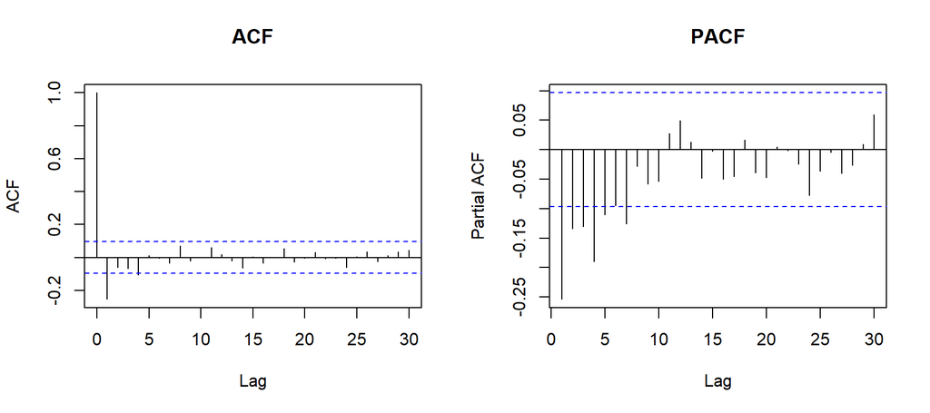

**Interpretasi:** Lag yang signifikan pada ACF: 1, 4. Lag yang signifikan pada PACF: 1, 2, 3, 4, 5, 7. Panduan membaca pola:

| Pola ACF | Pola PACF | Dugaan model |
| --- | --- | --- |
| Terpotong (*cuts off*) setelah lag q | Meluruh (*tails off*) | MA(q) |
| Meluruh (*tails off*) | Terpotong setelah lag p | AR(p) |
| Meluruh | Meluruh | ARMA(p, q) |

Cocokkan dengan grafik di atas untuk menentukan dugaan awal orde p dan q. Perlu diingat bahwa dengan banyak lag, sekitar 5% lag bisa signifikan hanya karena kebetulan.

## 6.2 EACF

```
#> AR/MA
#>   0 1 2 3 4 5 6
#> 0 x o o x o o o
#> 1 x o o x o o o
#> 2 x x o x o o o
#> 3 x x x o o o o
#> 4 x x x x o o o
#> 5 x x x x o o o
#> 6 x x x x o o o
```

**Interpretasi:** Pada tabel EACF, simbol **o** menandakan nilai tidak signifikan dan **x** menandakan signifikan. Orde ARMA(p, q) diduga dari titik sudut kiri atas segitiga simbol **o** (baris = orde AR, kolom = orde MA). Titik sudut tersebut beserta titik di sekitarnya menjadi kandidat model.

## 6.3 Daftar Model Kandidat

Untuk menjaga agar pemilihan sistematis dan tidak bergantung pada pembacaan visual saja, kandidat dibentuk dari seluruh kombinasi orde AR (p) dan MA (q) dari 0 sampai 2, kecuali model tanpa komponen AR dan MA. Kombinasi ini mencakup model-model yang biasanya diusulkan oleh ACF, PACF, dan EACF. Daftar kandidat dapat diubah di chunk berikut.

| Model | p | q |
| --- | --- | --- |
| ARIMA(1,1,0) | 1 | 0 |
| ARIMA(2,1,0) | 2 | 0 |
| ARIMA(0,1,1) | 0 | 1 |
| ARIMA(1,1,1) | 1 | 1 |
| ARIMA(2,1,1) | 2 | 1 |
| ARIMA(0,1,2) | 0 | 2 |
| ARIMA(1,1,2) | 1 | 2 |
| ARIMA(2,1,2) | 2 | 2 |

**Interpretasi:** Terdapat 8 model kandidat dengan d = 1. Model-model ini akan dibandingkan lewat uji signifikansi parameter dan nilai AIC pada tahap berikutnya.

# 7 Pendugaan Parameter, Signifikansi, dan AIC (Tahap 5)

Perbandingan model kandidat (diurutkan berdasarkan AIC)

| Model | AIC | BIC | Sigma2 | LogLik | Signifikan |
| --- | --- | --- | --- | --- | --- |
| ARIMA(1,1,1) | 800.8597 | 812.9228 | 0.4043 | -397.4299 | Ya |
| ARIMA(2,1,1) | 801.5042 | 817.5883 | 0.4038 | -396.7521 | Tidak |
| ARIMA(1,1,2) | 801.5895 | 817.6736 | 0.4039 | -396.7948 | Tidak |
| ARIMA(2,1,2) | 803.4587 | 823.5638 | 0.4048 | -396.7294 | Tidak |
| ARIMA(0,1,2) | 812.7175 | 824.7805 | 0.4164 | -403.3587 | Ya |
| ARIMA(0,1,1) | 830.5483 | 838.5904 | 0.4362 | -413.2742 | Ya |
| ARIMA(2,1,0) | 837.5193 | 849.5824 | 0.4426 | -415.7597 | Ya |
| ARIMA(1,1,0) | 843.2419 | 851.2840 | 0.4500 | -419.6210 | Ya |

**Interpretasi:** Tabel di atas membandingkan seluruh kandidat. Kolom *Signifikan* bernilai “Ya” bila **semua** koefisien AR/MA signifikan pada taraf 5%. Model yang baik memiliki AIC kecil sekaligus seluruh parameternya signifikan. Dari 8 model, sebanyak 5 model memiliki seluruh parameter signifikan.

## 7.1 Uji Signifikansi Parameter Tiap Model

Hipotesis untuk setiap parameter: H0: parameter = 0 (tidak signifikan) vs H1: parameter ≠ 0.

| Model | Parameter | Estimasi | SE | Z | P_value | Signifikan |
| --- | --- | --- | --- | --- | --- | --- |
| ARIMA(1,1,0) | ar1 | -0.2570 | 0.0479 | -5.3616 | 0.0000 | Ya |
| ARIMA(2,1,0) | ar1 | -0.2923 | 0.0491 | -5.9474 | 0.0000 | Ya |
| ARIMA(2,1,0) | ar2 | -0.1370 | 0.0491 | -2.7920 | 0.0052 | Ya |
| ARIMA(0,1,1) | ma1 | -0.4092 | 0.0672 | -6.0921 | 0.0000 | Ya |
| ARIMA(1,1,1) | ar1 | 0.5336 | 0.0876 | 6.0938 | 0.0000 | Ya |
| ARIMA(1,1,1) | ma1 | -0.9065 | 0.0560 | -16.1984 | 0.0000 | Ya |
| ARIMA(2,1,1) | ar1 | 0.5496 | 0.0601 | 9.1521 | 0.0000 | Ya |
| ARIMA(2,1,1) | ar2 | 0.0708 | 0.0566 | 1.2526 | 0.2103 | Tidak |
| ARIMA(2,1,1) | ma1 | -0.9455 | 0.0329 | -28.7316 | 0.0000 | Ya |
| ARIMA(0,1,2) | ma1 | -0.4179 | 0.0470 | -8.8921 | 0.0000 | Ya |
| ARIMA(0,1,2) | ma2 | -0.2362 | 0.0489 | -4.8310 | 0.0000 | Ya |
| ARIMA(1,1,2) | ar1 | 0.6699 | 0.0968 | 6.9176 | 0.0000 | Ya |
| ARIMA(1,1,2) | ma1 | -1.0643 | 0.1119 | -9.5117 | 0.0000 | Ya |
| ARIMA(1,1,2) | ma2 | 0.1108 | 0.0894 | 1.2389 | 0.2154 | Tidak |
| ARIMA(2,1,2) | ar1 | 0.4142 | 0.5459 | 0.7587 | 0.4480 | Tidak |
| ARIMA(2,1,2) | ar2 | 0.1466 | 0.3018 | 0.4858 | 0.6271 | Tidak |
| ARIMA(2,1,2) | ma1 | -0.8098 | 0.5483 | -1.4769 | 0.1397 | Tidak |
| ARIMA(2,1,2) | ma2 | -0.1254 | 0.5029 | -0.2494 | 0.8031 | Tidak |

**Interpretasi:** Parameter dengan p-value < 0.05 signifikan (H0 ditolak). Model yang memuat parameter tidak signifikan sebaiknya disederhanakan. Model dengan AR dan MA berorde sama (misalnya ARMA(2,2)) sering memiliki parameter yang saling meniadakan sehingga tidak signifikan.

## 7.2 Pemilihan Model Terbaik

Model terbaik dipilih dari model dengan **seluruh parameter signifikan** yang memiliki **AIC terkecil**. Bila tidak ada model yang seluruh parameternya signifikan, dipilih model dengan AIC terkecil.

```
#> [1] "ARIMA(1,1,1)"
```

```
#>
#> z test of coefficients:
#>
#>      Estimate Std. Error  z value  Pr(>|z|)
#> ar1  0.533621   0.087567   6.0938 1.102e-09 ***
#> ma1 -0.906530   0.055964 -16.1984 < 2.2e-16 ***
#> ---
#> Signif. codes:  0 '***' 0.001 '**' 0.01 '*' 0.05 '.' 0.1 ' ' 1
```

**Interpretasi:** Model terpilih adalah **ARIMA(1,1,1)** dengan AIC = 800.860. Seluruh parameter AR/MA pada model ini signifikan, sehingga model memenuhi kriteria signifikansi sekaligus memiliki AIC terkecil di antara model yang layak.

# 8 Analisis Sisaan (Tahap 6)

Model yang baik memiliki sisaan yang memenuhi asumsi: **berdistribusi normal, tidak berautokorelasi (white noise), berragam homogen, dan bernilai tengah nol**.

## 8.1 Eksplorasi Grafik Sisaan

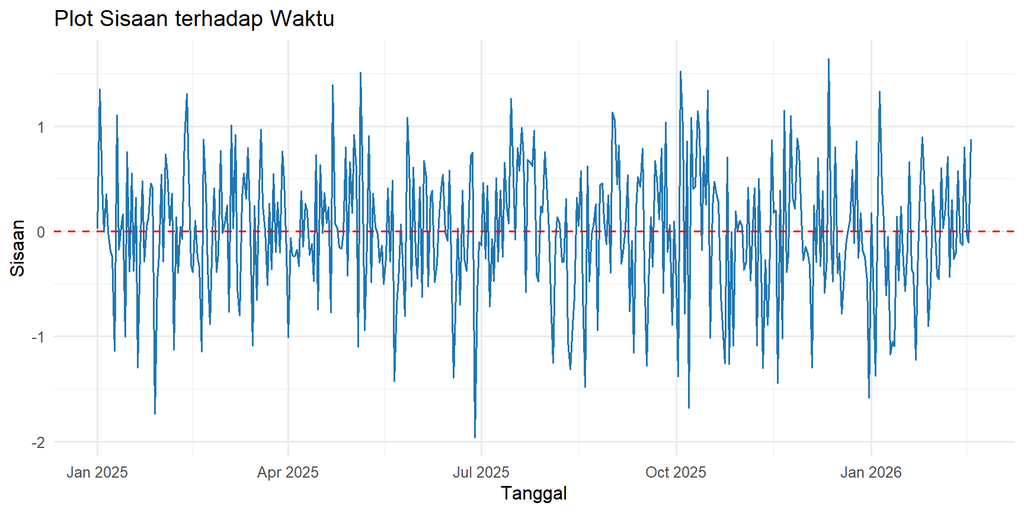

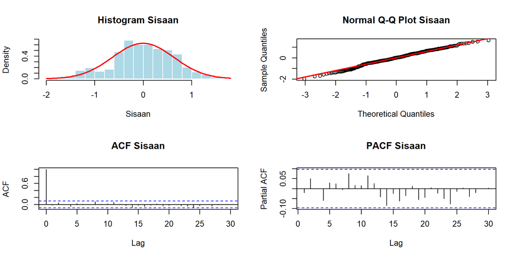

## 8.2 Uji Formal Asumsi Sisaan

| Asumsi | Uji | H0 | Statistik | P_value | Keputusan | Kesimpulan |
| --- | --- | --- | --- | --- | --- | --- |
| Normalitas | Shapiro-Wilk | Sisaan normal | 0.9935 | 0.0734 | Gagal tolak H0 | Asumsi terpenuhi |
| Normalitas | Jarque-Bera | Sisaan normal | 3.5723 | 0.1676 | Gagal tolak H0 | Asumsi terpenuhi |
| Normalitas | Kolmogorov-Smirnov | Sisaan normal | 0.0411 | 0.4865 | Gagal tolak H0 | Asumsi terpenuhi |
| Non-autokorelasi | Ljung-Box (lag 10) | Tidak ada autokorelasi | 6.1211 | 0.6337 | Gagal tolak H0 | Asumsi terpenuhi |
| Non-autokorelasi | Ljung-Box (lag 20) | Tidak ada autokorelasi | 14.8767 | 0.6704 | Gagal tolak H0 | Asumsi terpenuhi |
| Homoskedastisitas | Ljung-Box pada sisaan kuadrat (lag 10) | Tidak ada efek ARCH (ragam homogen) | 4.6242 | 0.9148 | Gagal tolak H0 | Asumsi terpenuhi |
| Nilai tengah nol | t-test satu sampel | Rata-rata sisaan = 0 | -0.1399 | 0.8888 | Gagal tolak H0 | Asumsi terpenuhi |

**Interpretasi:**

- **Normalitas:** Ketiga uji memberikan p-value >= alpha sehingga sisaan berdistribusi normal.
- **Non-autokorelasi:** Uji Ljung-Box tidak menolak H0, sehingga sisaan saling bebas (white noise). Artinya model sudah menangkap seluruh pola autokorelasi pada data.
- **Homoskedastisitas:** Tidak ditemukan efek ARCH, sehingga ragam sisaan homogen.
- **Nilai tengah nol:** Rata-rata sisaan tidak berbeda nyata dari nol.

# 9 Overfitting (Tahap 7)

Overfitting dicek dengan menambah satu orde pada model terpilih, yaitu ARIMA(p+1, d, q) dan ARIMA(p, d, q+1). Model terpilih dinilai **tidak overfit** bila koefisien tambahan **tidak signifikan** dan AIC tidak membaik secara berarti (penurunan AIC kurang dari sekitar 2).

Perbandingan model terpilih dengan model overfitting

| Model | AIC | Delta_AIC | Koef_tambahan | Estimasi | P_value | Signifikan |
| --- | --- | --- | --- | --- | --- | --- |
| ARIMA(1,1,1) (terpilih) | 800.8597 | 0.0000 | - | NA | NA | - |
| ARIMA(2,1,1) | 801.5042 | 0.6444 | ar2 | 0.0708 | 0.2103 | Tidak |
| ARIMA(1,1,2) | 801.5895 | 0.7298 | ma2 | 0.1108 | 0.2154 | Tidak |

```
#>
#>  ARIMA(2,1,1)
#>
#> z test of coefficients:
#>
#>      Estimate Std. Error  z value Pr(>|z|)
#> ar1  0.549595   0.060051   9.1521   <2e-16 ***
#> ar2  0.070839   0.056552   1.2526   0.2103
#> ma1 -0.945526   0.032909 -28.7316   <2e-16 ***
#> ---
#> Signif. codes:  0 '***' 0.001 '**' 0.01 '*' 0.05 '.' 0.1 ' ' 1
#>
#>
#>  ARIMA(1,1,2)
#>
#> z test of coefficients:
#>
#>      Estimate Std. Error z value  Pr(>|z|)
#> ar1  0.669932   0.096845  6.9176 4.595e-12 ***
#> ma1 -1.064301   0.111894 -9.5117 < 2.2e-16 ***
#> ma2  0.110793   0.089431  1.2389    0.2154
#> ---
#> Signif. codes:  0 '***' 0.001 '**' 0.01 '*' 0.05 '.' 0.1 ' ' 1
```

**Interpretasi:** Penambahan satu orde AR maupun MA pada ARIMA(1,1,1) tidak memberikan perbaikan yang berarti (koefisien tambahan tidak signifikan dan/atau AIC tidak turun lebih dari 2). Dengan demikian **model terpilih tidak mengalami overfitting** dan layak digunakan.

# 10 Peramalan (Tahap 8)

## 10.1 Peramalan pada Data Test

Peramalan dilakukan sebanyak panjang data test (103 hari). Hasil ramalan dikembalikan ke skala asli (invers Box-Cox bila tadi ditransformasi), lalu dibandingkan dengan data test.

Akurasi ramalan pada data test

|  | RMSE | MAE | MAPE_persen |
| --- | --- | --- | --- |
| ARIMA(1,1,1) | 1.552 | 1.373 | 5.169 |
| Benchmark: rata-rata data train | 0.955 | 0.775 | 2.941 |

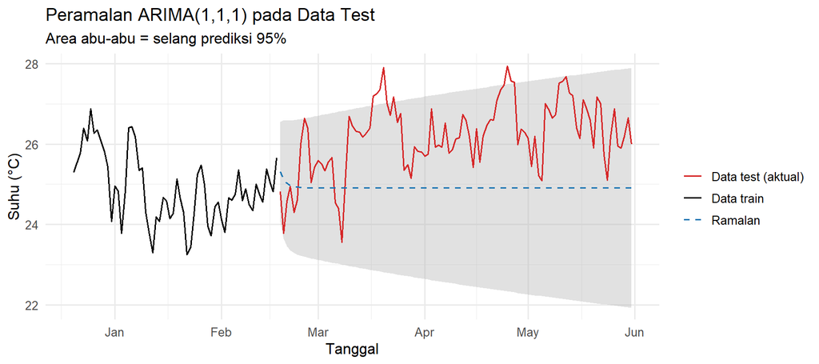

## 10.2 Peramalan ke Depan (30 Hari Setelah Data Terakhir)

Model dengan orde yang sama diestimasi ulang menggunakan **seluruh data** (train dan test), lalu digunakan untuk meramalkan 30 hari setelah tanggal terakhir data.

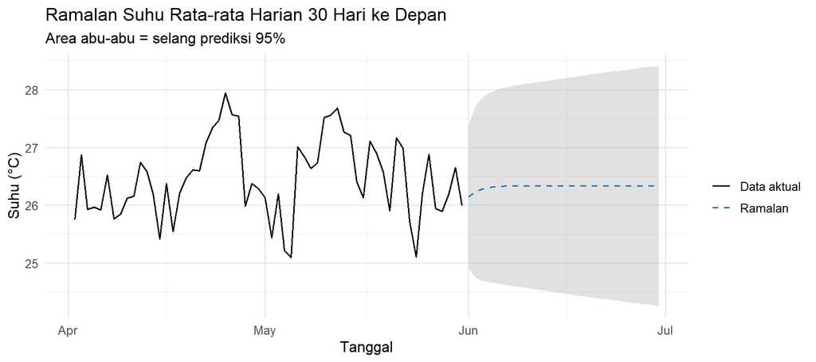

10 hari pertama hasil ramalan

| Tanggal | Forecast | Lower | Upper |
| --- | --- | --- | --- |
| 2026-06-01 | 26.15 | 24.91 | 27.39 |
| 2026-06-02 | 26.23 | 24.75 | 27.71 |
| 2026-06-03 | 26.28 | 24.70 | 27.86 |
| 2026-06-04 | 26.30 | 24.67 | 27.94 |
| 2026-06-05 | 26.32 | 24.65 | 27.99 |
| 2026-06-06 | 26.33 | 24.63 | 28.02 |
| 2026-06-07 | 26.33 | 24.62 | 28.05 |
| 2026-06-08 | 26.33 | 24.60 | 28.07 |
| 2026-06-09 | 26.34 | 24.58 | 28.09 |
| 2026-06-10 | 26.34 | 24.56 | 28.11 |

**Interpretasi:** Ramalan 30 hari ke depan (2026-06-01 s.d. 2026-06-30) berkisar antara 26.15 dan 26.34 °C. Selang prediksi 95% menunjukkan ketidakpastian ramalan: lebarnya sekitar 3.67 °C. Ramalan bersifat kurang bervariasi dibanding data aktual karena ARIMA hanya memanfaatkan pola autokorelasi dan tidak memuat faktor eksternal (musim, curah hujan, dan sebagainya).

# 11 Kesimpulan

1. **Data:** suhu per jam diagregasi menjadi rata-rata harian (516 hari), lalu dibagi menjadi 413 data train dan 103 data test.
2. **Kestasioneran:** selang kepercayaan Box-Cox ($\lambda$) pada data train adalah (-1.98; 2.46), sehingga tidak diperlukan transformasi (ragam sudah stasioner). Untuk rataan, differencing yang dipakai adalah d = 1.
3. **Model terpilih:** **ARIMA(1,1,1)** dengan AIC = 800.860, seluruh parameter AR/MA signifikan.
4. **Analisis sisaan:** asumsi normalitas terpenuhi, non-autokorelasi terpenuhi, homoskedastisitas terpenuhi, dan nilai tengah nol terpenuhi.
5. **Overfitting:** model terpilih tidak overfit.
6. **Akurasi ramalan (data test):** RMSE = 1.552 °C dan MAPE = 5.17%.